# Protocol variables

Descriptive analysis

Compounds included in document:

```
##  [1] "MEP"      "MiBP"     "MnBP"     "MBzP"     "MEHP"     "MEHHP"
##  [7] "MEOHP"    "MECPP"    "MMCHP"    "ohMiNP"   "oxoMiNP"  "cxMiNP"
## [13] "ohMINCH"  "oxoMINCH" "ohMPHP"
```

# 1 Intro

The protocol variables under study are:

- Batch
- Defreeze time
- Transport time

Number of urine samples by trimester

| period | n |
| --- | --- |
| T1 | 477 |
| T3 | 456 |

# 2 Batch

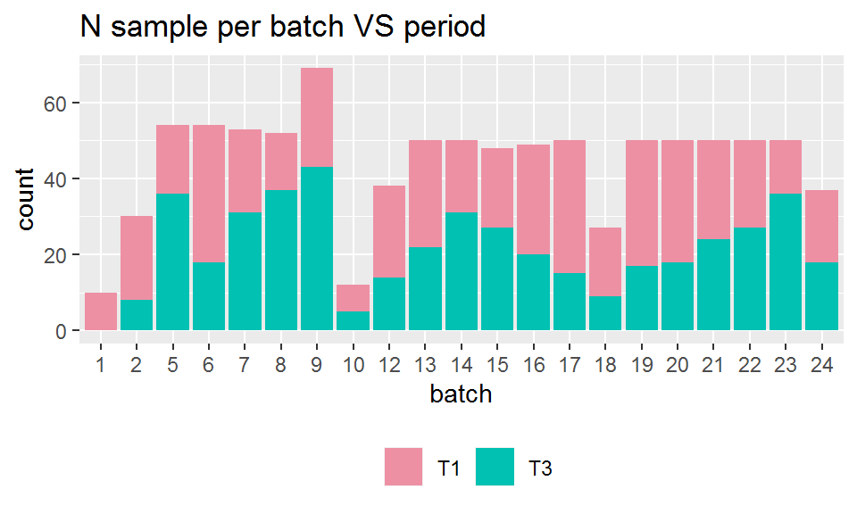

- Batch 9 used as reference

# 3 Defreeze time and transport time

Impossible values such as negative or null times were set to `NA`:

- N negative or null defreeze times: 10
- N negative or null transport times: 9

Transport time was log transformed due to strong skewness.

And defreeze times were used as tertiles because of the outliers that were pulling the trends.

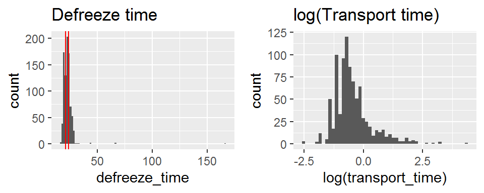

# 4 Censorship

Data below LOD will be imputed by *LOD/sqrt(2)*, OK when few number of samples < LOD.

| compound | n_below_lod |
| --- | --- |
| cxMiNP | 0 |
| MBzP | 0 |
| MECPP | 0 |
| MEHHP | 0 |
| MEHP | 1 |
| MEOHP | 0 |
| MEP | 0 |
| MiBP | 0 |
| MMCHP | 5 |
| MnBP | 0 |
| ohMINCH | 0 |
| ohMiNP | 0 |
| ohMPHP | 0 |
| oxoMINCH | 2 |
| oxoMiNP | 0 |

# 5 Raw level distributions

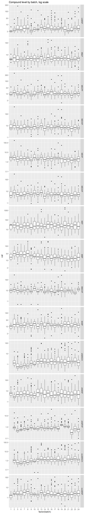

# 6 Associations with protocol vars

## 6.2 Method

A multiple linear regression is fit between compound level and the three protocol variables of interest and further adjusted on known confounding factors (cf. DAG + phenols paper):

- `specific_gravity`
- `sample_date` (linear time trend)
- `sample_season` (categorical)
- `period` (T1 vs T3)
- `mom_edu` (categorical)
- `mom_age` (continuous)
- `mom_bmi` (continuous)
- `parity` (continuous)

**Note: need to add occupation for bisphenols + tobacco**

Corrections are then applied to all protocol variables with p < 0.2 using the betas from this model following the procedure described in (Mortamais et al. 2012). A second correction will also take into account specific gravity.

## 6.3 Model outputs

Here are the p-values for the variables of interest from the multivariate model used to decide which protocol variables to use for correction.

p-values in the adjusted regressions

| compound | p_batch | p_def_time | p_trans_time |
| --- | --- | --- | --- |
| cxMiNP | 0 | 0.989 | 0.528 |
| MBzP | 0.334 | 0.119 | 0.81 |
| MECPP | 0 | 0.25 | 0.246 |
| MEHHP | 0.235 | 0.619 | 0.604 |
| MEHP | 0.039 | 0.573 | 0.963 |
| MEOHP | 0.025 | 0.804 | 0.407 |
| MEP | 0.037 | 0.978 | 0.767 |
| MiBP | 0 | 0.418 | 0.372 |
| MMCHP | 0 | 0.138 | 0.887 |
| MnBP | 0.014 | 0.569 | 0.81 |
| ohMINCH | 0 | 0.877 | 0.093 |
| ohMiNP | 0.164 | 0.077 | 0.778 |
| ohMPHP | 0 | 0.028 | 0.751 |
| oxoMINCH | 0 | 0.788 | 0.088 |
| oxoMiNP | 0.002 | 0.783 | 0.708 |